# 05-exercises

Your Name Here

2016-05-xx

## Reading:

- **APM** Chapter 8.6 and 8.8
- **APM** Chapter 14.8
- **APM** Chapter 7.1 & 7.3 “Non-Linear Regression Models”
- **APM** Chapter 13.2 & 13.4 “Non-Linear Classifcation Models”

## Fuel Economy

This week we return to the Fuel Economy Data having learned much about model building. This assignment is to go through the process of building several regression models and pick the most predictive model. Use the `FE` data set created for you above.

Start by making choosing a metric and making a naive guess of model performance:

Metric: *RMSE* Naive Guess: *35.03823* Expected Model Performance (based on Naive Guess): *8.096176*

Show your work below for the calculations

```r
# from hw 2

naive_guess <- mean(FE$FE)

rmse <- function(y,yhat) {
  ( y - yhat )^2  %>% mean %>% sqrt
}

err_naive_guess <- rmse(FE$FE, naive_guess)
err_naive_guess
```

```
## [1] 8.096176
```

Based only your intuition, how low do your think you can get your metric: *Let’s try to get it down to 3…*

## Examine your data

- Plot your response/outcome
- Make a guess of a strong predictor: *There’re three with a relatively wide range of values (EngDispl, NumCyl, and NumGears), I’m putting my money on EngDispl.*
- Plot your response vs your predictor.

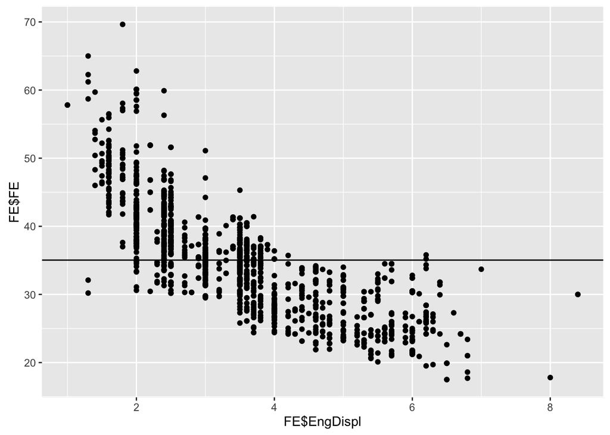

```r
qplot( y=FE$FE, x=FE$EngDispl ) + geom_hline(yintercept=naive_guess)
```

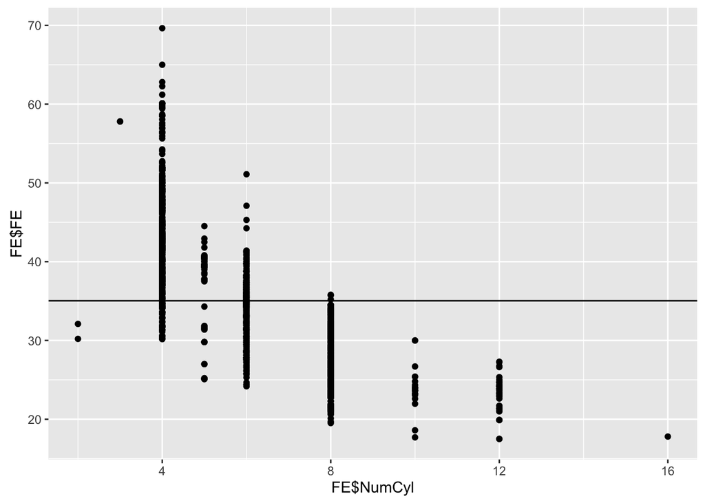

```r
qplot( y=FE$FE, x=FE$NumCyl ) + geom_hline(yintercept=naive_guess)
```

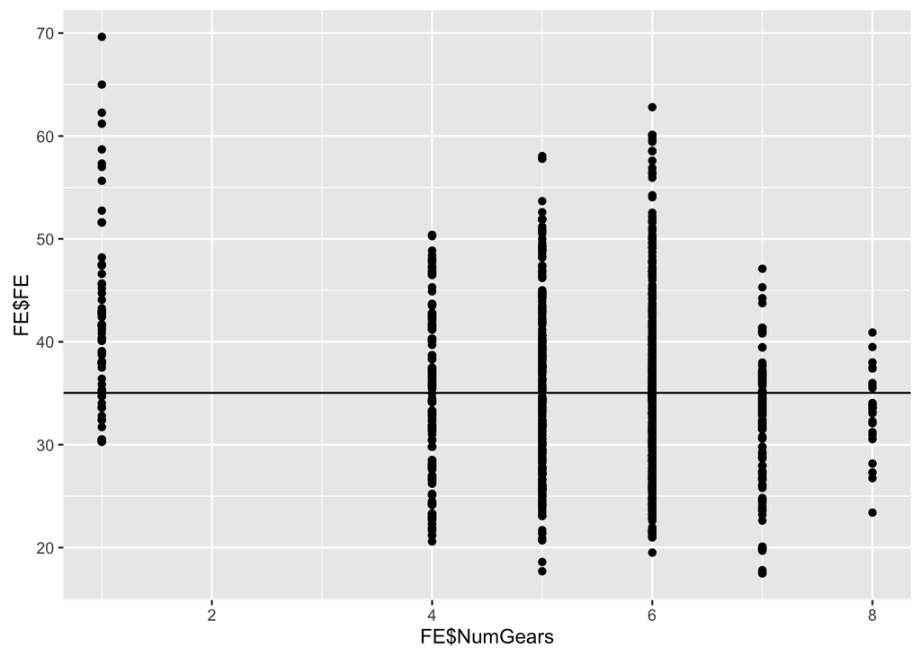

```r
qplot( y=FE$FE, x=FE$NumGears ) + geom_hline(yintercept=naive_guess)
```

```r
# Yep, EngDispl looks pretty tight!
```

## Build Simple Models

Using **caret**, build a simple linear model and a simple tree model.

```r
install.packages("caret", repos='http://cran.cnr.berkeley.edu/')
library(caret)
ctrl <- trainControl(method = "boot")

fit.lm <- train( FE ~ ., data=FE, trControl=ctrl, method="lm")
fit.lm$results  # RMSE=3.6665516
```

```
##   parameter     RMSE  Rsquared   RMSESD RsquaredSD
## 1      none 3.616686 0.8042725 0.149948 0.01202168
```

```r
fit.rp <- train( FE ~ ., data=FE, trControl=ctrl, method="rpart")
fit.rp$results  # RMSE=4.782416
```

```
##           cp     RMSE  Rsquared    RMSESD RsquaredSD
## 1 0.06355975 4.741736 0.6612201 0.2813252 0.03787761
## 2 0.13451886 5.305398 0.5730611 0.3895067 0.07652664
## 3 0.49666640 7.137749 0.4859834 1.1979093 0.02326772
```

What did you learn about the data from these models. *Simple lm is pretty good. We’ll have to work on the trees some more.*

## Build More Advanced Models

Now refine your models.

```r
# First, let's refine lm.
fit.lmTuned <- train( FE ~ ., data=FE, trControl=ctrl, method="lmStepAIC",  verbose=FALSE)
```

[output not shown]

[output not shown]

```r
fit.lm$results #RMSE = 3.653201
```

```
##   parameter     RMSE  Rsquared   RMSESD RsquaredSD
## 1      none 3.616686 0.8042725 0.149948 0.01202168
```

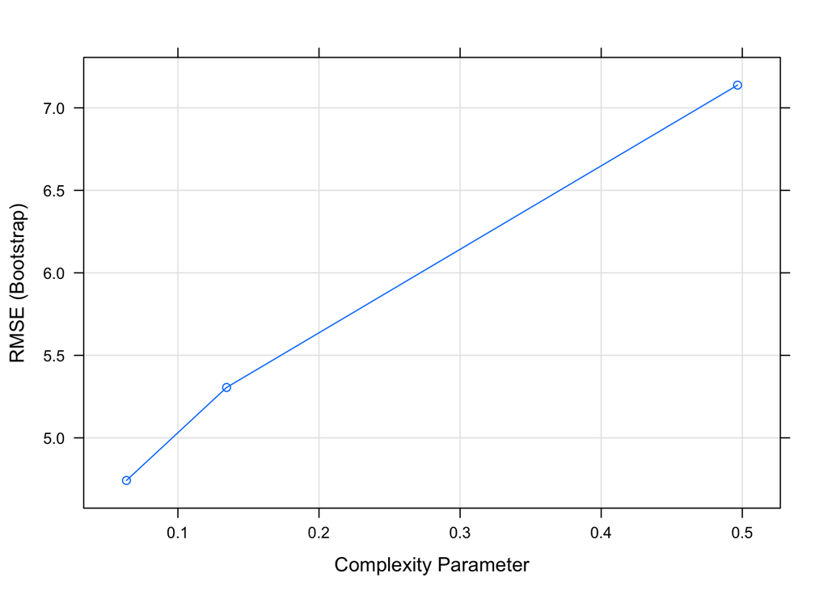

```r
# StepAIC offers no improvement over lm.

# Next, let's tune rp.
plot(fit.rp)
```

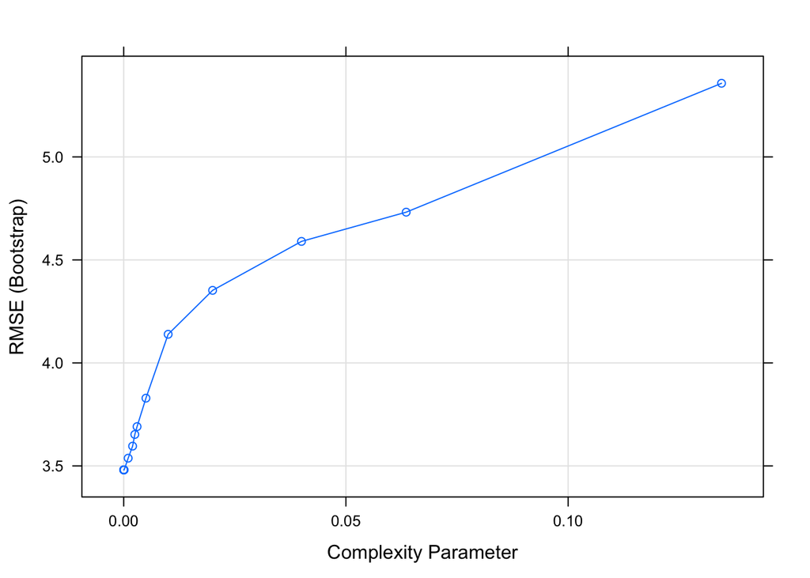

```r
# let's put more data points in the tuneGrid to see the performance curve better.
rpart.grid <- expand.grid(.cp=c(.00000001,.0000001,.000001,.00001,.0001,.001,.002,.0025,.003,.005,.01,.02,.04,.06355975,.13451886))
fit.rpTuned <- train( FE ~ ., data=FE, trControl=ctrl, method="rpart", tuneGrid=rpart.grid)
plot(fit.rpTuned)
```

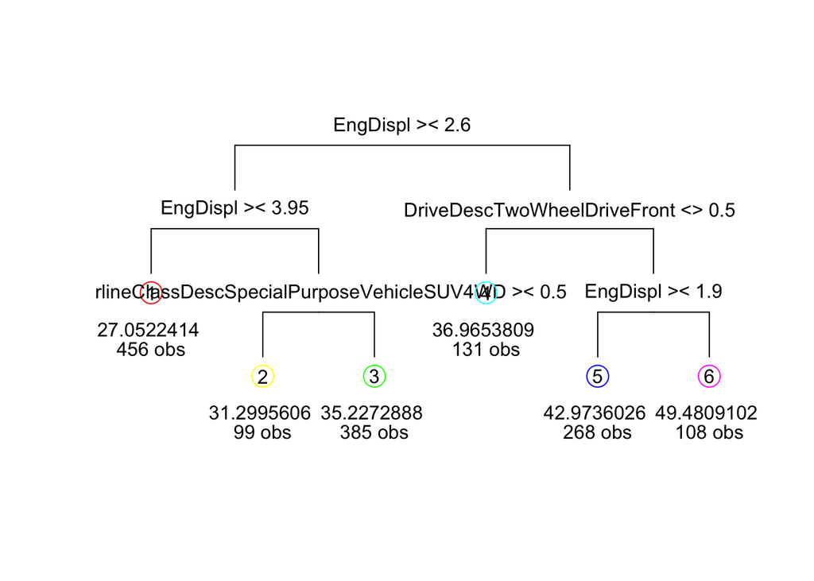

```r
# Looks like RMS error keeps decreasing as complexity goes up (ie as complexity parameter (cp) approaches 0).
# There's no obvious minimum to the curve, so use "one-standard error" method (Kuhn, p. 75).
fit.rpTuned <- train( FE ~ ., data=FE, trControl=ctrl, method="rpart1SE")
library(maptree)
draw.tree(fit.rpTuned$finalModel, nodeinfo = FALSE) # 6 terminal nodes... reasonable complexity
```

```r
fit.rpTuned$results #  RMSE = 4.142186, pretty bad
```

```
##   parameter     RMSE  Rsquared    RMSESD RsquaredSD
## 1      none 4.054764 0.7515911 0.1858599 0.01859082
```

Use **caret** to build advanced models: - one that uses model averaging (bagging) - one that uses boosting

```r
# For bagged trees, Kuhn talks about ipred (p. 215), which is listed as treebag on the caret model list.
fit.treebag <- train( FE ~ ., data=FE, trControl=ctrl, method="treebag")
fit.treebag$results # RMSE = 3.940785, not as good as lm.
```

```
##   parameter     RMSE  Rsquared    RMSESD RsquaredSD
## 1      none 3.932593 0.7667933 0.1417215 0.01700514
```

```r
fit.gbm <- train( FE ~ ., data=FE, trControl=ctrl, method="gbm", verbose=FALSE)
fit.gbm$results # RMSE = 3.283187, BEST SO FAR!
```

```
##   shrinkage interaction.depth n.minobsinnode n.trees     RMSE  Rsquared
## 1       0.1                 1             10      50 3.989979 0.7661828
## 4       0.1                 2             10      50 3.722029 0.7935153
## 7       0.1                 3             10      50 3.550090 0.8110417
## 2       0.1                 1             10     100 3.699136 0.7943180
## 5       0.1                 2             10     100 3.465388 0.8183797
## 8       0.1                 3             10     100 3.324766 0.8323351
## 3       0.1                 1             10     150 3.566294 0.8075797
## 6       0.1                 2             10     150 3.358139 0.8287656
## 9       0.1                 3             10     150 3.237160 0.8408517
##      RMSESD RsquaredSD
## 1 0.1615451 0.01334021
## 4 0.1616340 0.01431140
## 7 0.1656250 0.01443371
## 2 0.1627652 0.01354841
## 5 0.1662174 0.01498372
## 8 0.1630791 0.01405053
## 3 0.1606867 0.01374390
## 6 0.1671168 0.01511526
## 9 0.1705999 0.01503181
```

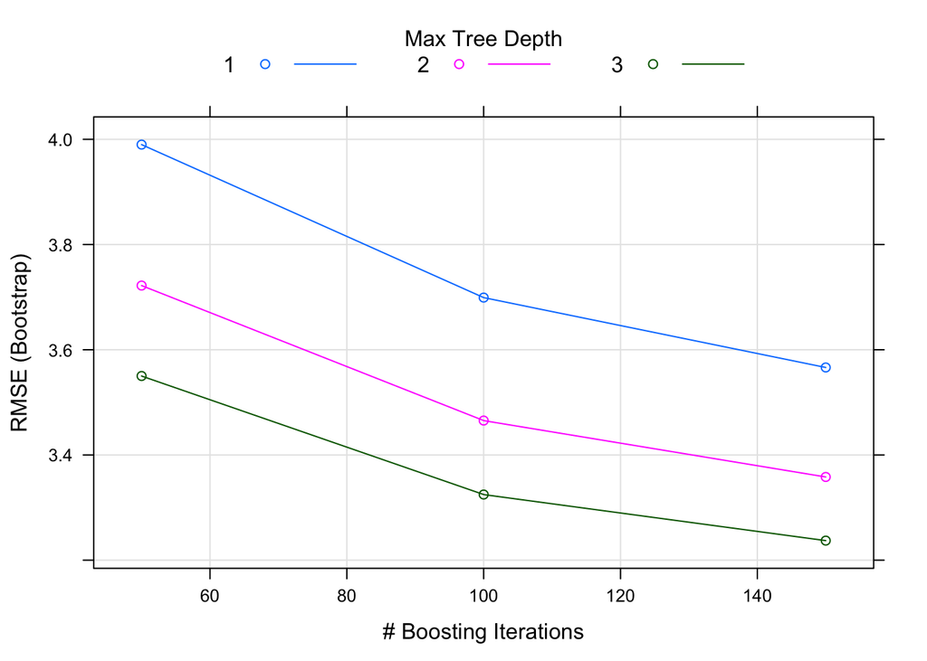

```r
plot(fit.gbm)
```

```r
# started with parameters from p. 217... kept tuning
# more trees, deeper should help
gbm.grid <- expand.grid(
              .shrinkage = .1,
              .interaction.depth = 7,
              .n.minobsinnode = 10,
              .n.trees = 350
              )
fit.gbmTuned <- train( FE ~ ., data=FE, trControl=ctrl, method="gbm", verbose=FALSE, tuneGrid=gbm.grid)
fit.gbmTuned$results #RMSE = 2.889891
```

```
##   shrinkage interaction.depth n.minobsinnode n.trees     RMSE  Rsquared
## 1       0.1                 7             10     350 2.864919 0.8761605
##      RMSESD RsquaredSD
## 1 0.1586286 0.01237153
```

## Conclusion

Which model would you use and why? Under different circumstances why would you choose one of the other models.

- gbm has the best performance. We hit our target of under 3. However, it is more opaque. If explainability is important, rpart and lm might be better. *